# WB-2026-05 · Multi-Tenant e White-Label: Quando Vale a Pena Escalar

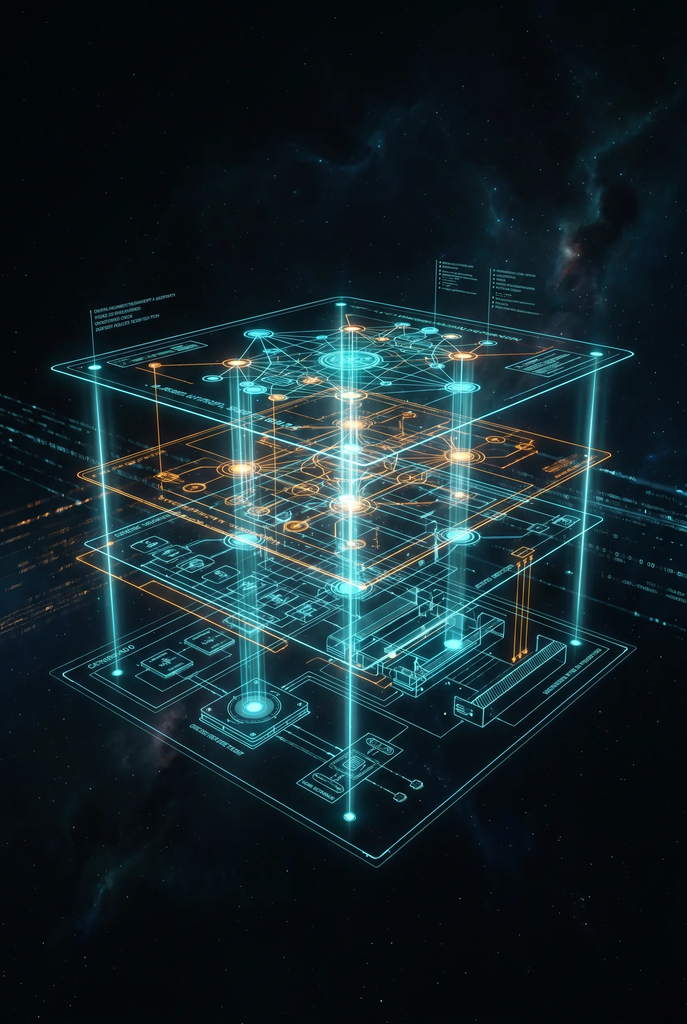

Capa — Multi-Tenant e White-Label

**WB-2026-05 · Multi-Tenant e White-Label: Quando Vale a Pena Escalar**

*Cases reais de quem saiu de operador único para white-label. Decisão técnica, decisão de negócio, e o que ninguém te conta sobre escala.*

**Por Equipe Nexus · Academ’IA**

Nexus Affil’IA’te · 2026

**Sobre este webinar**

White-label é o **topo da pirâmide Elite**. Você deixa de ser afiliado e vira **operador de plataforma**. Mas a jornada é complexa, e 70% dos que tentam falham nos primeiros 6 meses.

Neste webinar, **2 cases reais** vão contar o que deu certo, o que deu errado, e como decidir se vale a pena para VOCÊ.

# 🎯 Sumário

> **•** 1. O que é multi-tenant (e o que NÃO é) **•** 2. Os 3 modelos de white-label **•** 3. Case 1 — Multi-tenant vertical (mesmo nicho, múltiplos clientes) **•** 4. Case 2 — White-label horizontal (mesma plataforma, múltiplos nichos) **•** 5. Quando **NÃO** vale a pena **•** 6. Os 5 custos escondidos **•** 7. Como precificar **•** 8. Arquitetura técnica mínima **•** 9. Os 3 erros que matam o white-label **•** 10. Q&A ao vivo (30 minutos)

**1. O que é multi-tenant (e o que NÃO é)**

**Multi-tenant** = 1 sistema rodando para múltiplos clientes (tenants), com isolamento de dados.

**O que NÃO é**: - ❌ Multi-instância (cada cliente tem sua própria cópia do sistema) — é caro, não escala - ❌ Single-tenant compartilhado (todos no mesmo banco sem isolamento) — é perigoso - ❌ “Compartilhar API” (vários clientes usam 1 chave de API) — é ilegal (LGPD)

**O que É**: - ✅ 1 banco com schema isolado por tenant (ou schema compartilhado com `tenant_id` em cada tabela) - ✅ 1 camada de aplicação que roteia requests baseado no tenant - ✅ Billing e rate limits separados por tenant - ✅ Autenticação isolada (cada tenant tem seus próprios usuários)

**2. Os 3 modelos de white-label**

**Modelo A — Vertical** (mesmo nicho, múltiplos clientes) - Você vende para **várias empresas do mesmo setor** - Exemplo: você constrói plataforma de marketing para 10 clínicas - Vantagem: você vira especialista, reúsa código/skills - Desvantagem: pequeno TAM (Total Addressable Market)

**Modelo B — Horizontal** (mesma plataforma, múltiplos nichos) - Você vende para **qualquer empresa** - Exemplo: você constrói plataforma genérica e vende para qualquer vertical - Vantagem: TAM gigante - Desvantagem: precisa generalizar tudo (perde profundidade)

**Modelo C — Plataforma** (outros devs constroem em cima) - Você vende a **infraestrutura**, outros constroem apps - Exemplo: você expõe API + dashboard, e terceiros criam skills - Vantagem: escalável infinitamente - Desvantagem: requer API design forte + governança

**3. Case 1 — Beatriz e o Multi-Tenant Vertical**

Beatriz (a mesma do WB-2026-04) decidiu, em janeiro/2026, virar multi-tenant. Ela atende **8 clínicas de odontologia** em São Paulo.

**Decisão técnica**: - Schema compartilhado com `clinic_id` em cada tabela - 1 banco Postgres, 1 Redis, 1 Judge global + 1 Judge por clínica (configurações diferentes) - Billing: 1 fatura por clínica (R$ 4.500/mês cada)

**O que funcionou**: - Padronização: 1 copy template por especialidade (ortodontia, implante, etc) - Compartilhamento de skills: 1 copywriter serve todas, mas com few-shot específicos - Judge isolado por clínica (cada uma tem suas regras de compliance)

**O que quebrou**: - Latência subiu 2x quando passou de 4 para 8 clínicas (precisou escalar) - 1 clínica pediu dados em formato específico (quebra de padrão) - Backup: passou de 1 para 8 (custo subiu 8x)

**Lição**: vertical escala bem até **~20 clientes**. Depois, precisa repensar.

**4. Case 2 — Carlos e o White-Label Horizontal**

Carlos (do WB-2026-04) fez a aposta mais agressiva: white-label horizontal. Em mar/2026, lançou **OperIA** — uma plataforma genérica que qualquer empresa pode usar.

**Decisão técnica**: - Multi-tenant com schema isolado (cada cliente tem seu próprio banco) - 8 skills prontas (configuráveis por tenant) - Dashboard white-label (cliente coloca logo + cores) - API pública (outros devs constroem integrações)

**O que funcionou**: - 23 clientes em 4 meses (10 verticais diferentes) - Pricing tiers: R$ 297/mês (básico), R$ 997/mês (pro), R$ 2.997/mês (enterprise) - 70% dos clientes vieram de referral (clientes existentes indicam)

**O que quebrou**: - Suporte: 23 clientes = 23× suporte. Contratou 2 pessoas (R$ 8k/mês) - Drift de configuração: cada cliente customiza, vira “fork” da plataforma - Compliance: precisa lidar com LGPD + HIPAA (EUA) + GDPR (Europa) — virou especialista

**Custos reais**: - Infra: R$ 4.500/mês - Time: R$ 14k/mês (Carlos + 2 suporte) - Faturamento: R$ 18k/mês (sozinho) → R$ 38k/mês (OperIA, 4 meses depois) - Margem: 38 - 18.5 = **R$ 19.5k/mês líquido** (vs R$ 13k líquido antes)

**Lição**: horizontal exige **escala mínima de 15-20 clientes** para valer a pena. Abaixo disso, é prejuízo.

**5. Quando NÃO vale a pena**

Depois de ouvir os 2 cases, fica claro que white-label **não é para todos**:

❌ **Se você fatura < R$ 30k/mês** como afiliado: você ainda não tem product-market fit. Escale primeiro.

❌ **Se você não tem skill de gestão**: white-label é um negócio. Você precisa saber contratar, cobrar, suportar.

❌ **Se você não tem paciência**: os primeiros 3 meses são **prejuízo garantido**. Você está construindo plataforma, não vendendo.

❌ **Se você é sozinho**: white-label horizontal **exige time**. Mínimo 1 dev + 1 suporte + 1 comercial.

✅ **Vale a pena se**: - Você fatura R$ 30k+/mês e quer **escalar sem aumentar tempo** - Você tem product-market fit validado (clientes pedem mais do que você entrega) - Você tem R$ 50-100k de reserva para 6 meses de investimento - Você aceita que é **outro negócio**, não mais afiliados

**6. Os 5 custos escondidos**

Nenhum tutorial fala destes:

1. **Suporte** — clientes exigem resposta < 4h. Contrate antes, não depois.
2. **Compliance legal** — cada vertical tem regulação. LGPD é só o começo.
3. **Drift de configuração** — cada cliente quer “diferente”. Sem padrão, vira bagunça.
4. **Onboarding** — 30% dos clientes cancelam no primeiro mês por não saber usar. Invista em tutorial.
5. **Churn** — white-label tem churn alto (5-10%/mês). Calcule LTV antes de escalar.

**7. Como precificar**

**Beatriz (vertical)** cobra: - Setup: R$ 5.000 (one-time) - Mensal: R$ 4.500 (inclui 3 skills + Judge + suporte 24h) - Adicional: R$ 800/skill extra

**Carlos (horizontal)** cobra: - Basic: R$ 297/mês (3 skills + Judge padrão) - Pro: R$ 997/mês (8 skills + Judge custom + API) - Enterprise: R$ 2.997/mês (skills ilimitadas + SLA 99.9% + suporte dedicado)

**Regra geral**: seu preço deve ser **5-10% do LTV do cliente**. Se cliente fatura R$ 50k/mês, cobra R$ 2.5-5k/mês.

**8. Arquitetura técnica mínima**

Se você decidir ir, a stack mínima é:

```
┌────────────────────────────────────────────┐
│  Auth (Auth0 ou Clerk ou Supabase Auth)    │
└────────────┬───────────────────────────────┘
             ↓
┌────────────────────────────────────────────┐
│  API Gateway (Kong ou AWS API GW)          │
│  - Rate limit por tenant                   │
│  - Logging centralizado                    │
└────────────┬───────────────────────────────┘
             ↓
┌────────────────────────────────────────────┐
│  App Multi-Tenant (Node ou Python)         │
│  - Tenant resolver (header → DB lookup)    │
│  - Context injection em cada request       │
└────────────┬───────────────────────────────┘
             ↓
┌────────────────────────────────────────────┐
│  DB com isolamento                         │
│  - Opção A: schema por tenant (Postgres)   │
│  - Opção B: tenant_id em cada tabela       │
│  - Backup separado por tenant              │
└────────────────────────────────────────────┘
```

**Plus**: - Billing: Stripe (com subscription por tenant) - Logs: Datadog ou Grafana Cloud (separado por tenant) - Monitoring: Sentry (com tag de tenant) - Compliance: Vanta ou Drata (LGPD/SOC2)

**9. Os 3 erros que matam o white-label**

**Erro 1 — Começar sem product-market fit** Você não testou a demanda. Lança plataforma e ninguém compra. Solução: **valide primeiro** com 5-10 clientes pagantes em modo manual.

**Erro 2 — Multi-tenant antes do single-tenant funcionar** Você quer escalar antes de ter 1 cliente satisfeito. Solução: **opere single-tenant até ter 10 clientes pagantes** satisfeitos. Depois, refatore.

**Erro 3 — Cobrar barato demais** Você precifica R$ 97/mês achando que é acessível. Mas R$ 97 não paga seu suporte. Solução: **comece em R$ 497+** e justifique com ROI claro.

**10. Q&A ao vivo (30 minutos)**

Os convidados já confirmaram que vão responder sobre: - Quanto cobrar em diferentes nichos - Quando contratar o primeiro funcionário - Como migrar clientes existentes para o white-label - Como evitar o “drift de configuração” - Quando desistir (se o white-label não está funcionando)

# 📋 Especificações do Webinar

| Item | Detalhe |
| --- | --- |
| **Data prevista** | 29 de julho de 2026 |
| **Duração** | 90-120 minutos |
| **Formato** | Ao vivo via Zoom + YouTube Live |
| **Gravação** | Liberada 48h após |
| **Inscrição** | R$ 97 (gratuito para membros Elite) |
| **Pré-requisito** | Curso 01-multi-tenant-whitelabel.md |
| **Público-alvo** | Alunos da Trilha Elite, ou afiliados faturando R$ 30k+/mês |

# 🎓 O que você vai sair sabendo

1. Quando **vale** e quando **NÃO vale** a pena virar white-label.
2. Os **3 modelos** (vertical, horizontal, plataforma) — prós e contras.
3. **5 custos escondidos** que ninguém conta.
4. Como **precificar** de forma lucrativa.
5. A **arquitetura técnica mínima** para começar.
6. Os **3 erros que matam** 70% dos white-labels.

# 🎯 CTA Pós-Webinar

- Curso **01-multi-tenant-whitelabel.md**: revise antes do webinar
- Apostila **01 — Infraestrutura**: para entender a stack
- Curso **02-federacao-agentes.md**: complemento sobre escala horizontal

*WB-2026-05 · Multi-Tenant e White-Label*

*Por MMN AI-to-AI · 2026 · Licença: CC BY-SA 4.0*

*“White-label não é sobre tecnologia. É sobre decidir se você quer ser operador ou plataforma. E essas são duas carreiras completamente diferentes.”*